[O’Hara on GitHub](https://github.com/oharac)

# Compare cumulative impacts per species to IUCN status

Compiled on Thu Apr 20 07:13:41 2023 by ohara

```r
knitr::opts_chunk$set(echo = TRUE, message = FALSE, warning = FALSE)

library(tidyverse)
library(here)
library(oharac)
source(here('common_fxns.R'))
```

# 1 Summary

Calculate the cumulative impact across each species range (total and coastal-only). Relative CHI will be the total CHI (summed across all cells and all stressors) normalized by the total range (total and coastal-only). The relative CHI is effectively the average CHI per km<sup>2</sup> across the species’ range.

Perform a regression of IUCN extinction risk classification as a function of relative overall CHI and overall range, and then do the same for coastal.

# 2 Data

- Species impact scores from script 6
- IUCN extinction risk scores from IUCN

# 3 Methods

## 3.1 Read in species impacts for those spp assessed by IUCN; summarize to CHI

Summarize to cumulative impacts by entire range and by coastal range.

Each file has a row for each stressor-vulnerability match; columns are:

- `str_vuln` (chr): name of stressor/vuln combo, as -
- `impact_tot` (dbl): sum across all cells of stressor intensity $\times$ vulnerability $\times$ ocean area
- `impact_coastal` (dbl): sum across all coastal cells (≤200m) of stressor intensity $\times$ vulnerability $\times$ ocean area
- `range_tot_km2` (dbl): sum of ocean area of all cells across entire range
- `range_coastal_km2` (dbl): sum of ocean area of all cells across coastal range

```r
spp_chi_file <- here_anx('int/spp_chi_summary.csv')

if(!file.exists(spp_chi_file)) { ### unlink(spp_chi_file)
  spp_imp_fs <- list.files(here_anx('impacts_by_species'),
                           pattern = '^impacts_.+.csv', full.names = TRUE)

  spp_imp_raw_df <- parallel::mclapply(spp_imp_fs, mc.cores = 40,
                                       data.table::fread) %>%
    setNames(basename(spp_imp_fs)) %>%
    data.table::rbindlist(idcol = 'f') %>%
    rename(vuln = vulnerability)

  spp_ranges <- spp_imp_raw_df %>%
    select(f, range_a_km2, range) %>%
    distinct() %>%
    spread(range, range_a_km2) %>%
    rename(range_cst_km2 = coastal, range_tot_km2 = full)

  spp_npp_ranges <- spp_imp_raw_df %>%
    select(f, npp_range_km2, range) %>%
    distinct() %>%
    spread(range, npp_range_km2) %>%
    rename(npp_range_cst_km2 = coastal, npp_range_tot_km2 = full)

  spp_ln_npp_ranges <- spp_imp_raw_df %>%
    select(f, ln_npp_range_km2, range) %>%
    distinct() %>%
    spread(range, ln_npp_range_km2) %>%
    rename(ln_npp_range_cst_km2 = coastal, ln_npp_range_tot_km2 = full)

  spp_intensity_df <- spp_imp_raw_df %>%
    select(f, vuln, stressor, intensity_tot, range) %>%
    spread(range, intensity_tot) %>%
    rename(intensity_tot = full, intensity_cst = coastal)

  spp_intens_cv_df <- spp_imp_raw_df %>%
    select(f, vuln, stressor, intensity_cv, range) %>%
    spread(range, intensity_cv) %>%
    rename(intensity_cv_tot = full, intensity_cv_cst = coastal)

  spp_npp_intensity_df <- spp_imp_raw_df %>%
    select(f, vuln, stressor, int_npp_tot, range) %>%
    spread(range, int_npp_tot) %>%
    rename(int_npp_tot = full, int_npp_cst = coastal)

  spp_npp_intens_cv_df <- spp_imp_raw_df %>%
    select(f, vuln, stressor, int_npp_cv, range) %>%
    spread(range, int_npp_cv) %>%
    rename(int_npp_cv_tot = full, int_npp_cv_cst = coastal)

  spp_ln_npp_intensity_df <- spp_imp_raw_df %>%
    select(f, vuln, stressor, int_ln_npp_tot, range) %>%
    spread(range, int_ln_npp_tot) %>%
    rename(int_ln_npp_tot = full, int_ln_npp_cst = coastal)

  spp_ln_npp_intens_cv_df <- spp_imp_raw_df %>%
    select(f, vuln, stressor, int_ln_npp_cv, range) %>%
    spread(range, int_ln_npp_cv) %>%
    rename(int_ln_npp_cv_tot = full, int_ln_npp_cv_cst = coastal)

  spp_impacts_df <- spp_imp_raw_df %>%
    select(f, vuln, stressor, impact_tot, range) %>%
    spread(range, impact_tot) %>%
    rename(impact_tot = full, impact_cst = coastal)

  spp_cv_df <- spp_imp_raw_df %>%
    select(f, vuln, stressor, impact_cv, range) %>%
    spread(range, impact_cv) %>%
    rename(impact_cv_tot = full, impact_cv_cst = coastal)

  spp_impacts_npp_df <- spp_imp_raw_df %>%
    select(f, vuln, stressor, impact_npp_tot, range) %>%
    spread(range, impact_npp_tot) %>%
    rename(impact_npp_tot = full, impact_npp_cst = coastal)

  spp_npp_cv_df <- spp_imp_raw_df %>%
    select(f, vuln, stressor, impact_npp_cv, range) %>%
    spread(range, impact_npp_cv) %>%
    rename(impact_npp_cv_tot = full, impact_npp_cv_cst = coastal)

  spp_impacts_ln_npp_df <- spp_imp_raw_df %>%
    select(f, vuln, stressor, imp_ln_npp_tot, range) %>%
    spread(range, imp_ln_npp_tot) %>%
    rename(impact_ln_npp_tot = full, impact_ln_npp_cst = coastal)

  spp_ln_npp_cv_df <- spp_imp_raw_df %>%
    select(f, vuln, stressor, imp_ln_npp_cv, range) %>%
    spread(range, imp_ln_npp_cv) %>%
    rename(impact_ln_npp_cv_tot = full, impact_ln_npp_cv_cst = coastal)

  iucn_worms_lookup <- read_csv(here('_data/iucn_spp', 'iucn_to_worms_match.csv'))

  spp_imp_cv_df <- full_join(spp_impacts_df, spp_cv_df,
                             by = c('f', 'vuln', 'stressor')) %>%
    full_join(spp_impacts_npp_df, by = c('f', 'vuln', 'stressor')) %>%
    full_join(spp_npp_cv_df, by = c('f', 'vuln', 'stressor')) %>%
    full_join(spp_impacts_ln_npp_df, by = c('f', 'vuln', 'stressor')) %>%
    full_join(spp_ln_npp_cv_df, by = c('f', 'vuln', 'stressor')) %>%
    full_join(spp_intensity_df, by = c('f', 'vuln', 'stressor')) %>%
    full_join(spp_intens_cv_df, by = c('f', 'vuln', 'stressor')) %>%
    full_join(spp_npp_intensity_df, by = c('f', 'vuln', 'stressor')) %>%
    full_join(spp_npp_intens_cv_df, by = c('f', 'vuln', 'stressor')) %>%
    full_join(spp_ln_npp_intensity_df, by = c('f', 'vuln', 'stressor')) %>%
    full_join(spp_ln_npp_intens_cv_df, by = c('f', 'vuln', 'stressor')) %>%
    left_join(spp_ranges, by = 'f') %>%
    left_join(spp_npp_ranges, by = 'f') %>%
    left_join(spp_ln_npp_ranges, by = 'f') %>%
    ### extract species and map info from filename
    mutate(map_src = str_extract(f, '_iucn_|_am_') %>% str_remove_all('_'),
           iucn_sid = str_extract(f, '[0-9]+') %>% as.integer(),
           spp_from_f = str_remove_all(f, 'impacts_(am|iucn)_|.csv')) %>%
    left_join(iucn_worms_lookup, by = 'iucn_sid') %>%
    mutate(sciname = ifelse(is.na(worms_name),
                            str_replace_all(spp_from_f, '_', ' '),
                            worms_name)) %>%
    ### append iucn_sid for spp not mapped in IUCN but mapped in AM:
    left_join(iucn_worms_lookup %>% select(sciname = worms_name, iucn_sid2 = iucn_sid),
              by = c('sciname')) %>%
    mutate(iucn_sid = ifelse(is.na(iucn_sid), iucn_sid2, iucn_sid)) %>%
    select(sciname, iucn_sid, map_src, vuln, stressor,
           impact_cst, impact_tot, impact_cv_cst, impact_cv_tot,
           impact_npp_cst, impact_npp_tot,
           impact_npp_cv_cst, impact_npp_cv_tot,
           impact_ln_npp_cst, impact_ln_npp_tot,
           impact_ln_npp_cv_cst, impact_ln_npp_cv_tot,
           intensity_cst, intensity_tot,
           intensity_cv_cst, intensity_cv_tot,
           int_npp_cst, int_npp_tot,
           int_npp_cv_cst, int_npp_cv_tot,
           int_ln_npp_cst, int_ln_npp_tot,
           int_ln_npp_cv_cst, int_ln_npp_cv_tot,
           range_cst_km2, range_tot_km2,
           npp_range_cst_km2, npp_range_tot_km2,
           ln_npp_range_cst_km2, ln_npp_range_tot_km2) %>%
    distinct() %>%
    filter(range_tot_km2 > 0 & !is.na(impact_tot))

  write_csv(spp_imp_cv_df, spp_chi_file)
}
```

## 3.2 Examine means across taxa

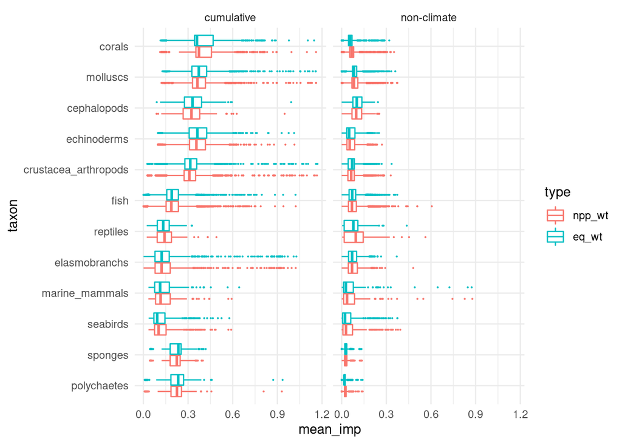

```r
vuln_taxa <- get_spp_vuln() %>%
  select(species, taxon) %>%
  distinct()

spp_impacts <- read_csv(spp_chi_file) %>%
  filter(range_tot_km2 > 10000)

spp_chi <- spp_impacts %>%
  filter(stressor == 'cumulative') %>%
  mutate(eq_wt  = impact_tot / range_tot_km2,
         npp_wt = impact_npp_tot / npp_range_tot_km2) %>%
  select(sciname, eq_wt, npp_wt, range_tot_km2) %>%
  distinct() %>%
  mutate(group = 'cumulative')

spp_no_cc <- spp_impacts %>%
  filter(vuln == 'stressor_group' & stressor != 'climate') %>%
  select(sciname, impact_tot, impact_npp_tot, range_tot_km2, npp_range_tot_km2) %>%
  distinct() %>%
  mutate(imp_unwt_tot = impact_tot / range_tot_km2,
         imp_nppwt_tot = impact_npp_tot / npp_range_tot_km2) %>%
  group_by(sciname) %>%
  summarize(eq_wt  = sum(imp_unwt_tot),
            npp_wt = sum(imp_nppwt_tot),
            range_tot_km2 = first(range_tot_km2)) %>%
  mutate(group = 'non-climate')

cum_plus_non_cc <- bind_rows(spp_chi, spp_no_cc) %>%
  left_join(vuln_taxa, by = c('sciname' = 'species')) %>%
  gather(type, mean_imp, eq_wt, npp_wt) %>%
  filter(!is.na(taxon))

taxon_order <- cum_plus_non_cc %>%
  filter(type == 'eq_wt') %>%
  group_by(taxon) %>%
  summarize(med_imp = median(mean_imp)) %>%
  arrange(med_imp) %>%
  .$taxon

plot_df <- cum_plus_non_cc %>%
  mutate(taxon = factor(taxon, levels = taxon_order)) %>%
  mutate(type = factor(type, levels = c('npp_wt', 'eq_wt')))

ggplot(plot_df,
       aes(y = taxon, x = mean_imp)) +
  geom_boxplot(aes(color = type),
               outlier.size = .1) +
  theme_minimal() +
  facet_wrap( ~ group)
```

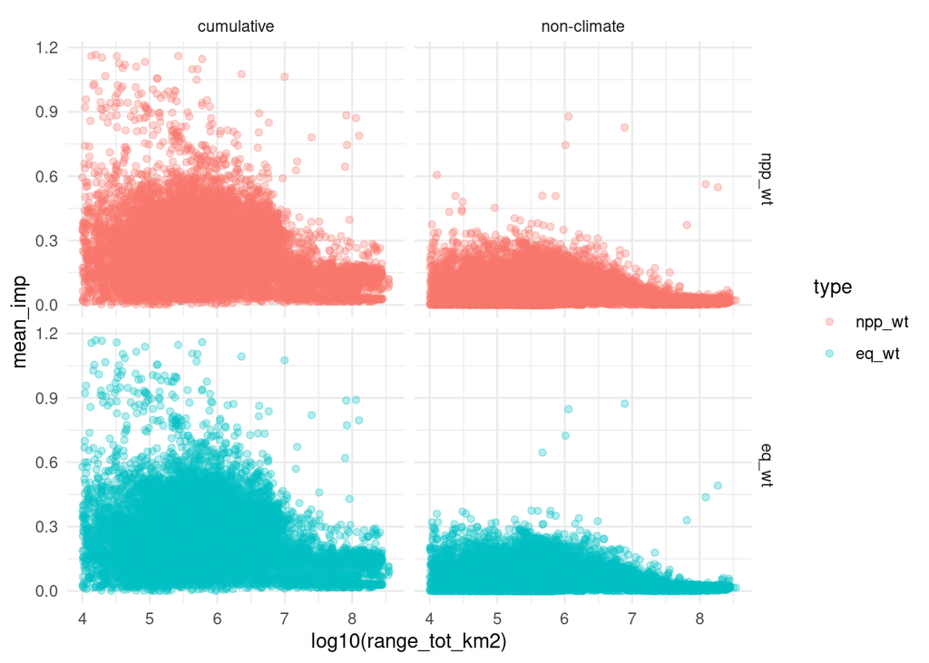

```r
ggplot(plot_df, aes(x = log10(range_tot_km2), y = mean_imp)) +
  geom_point(aes(color = type), alpha = .3) +
  theme_minimal() +
  facet_grid(type ~ group)
```

```r
summary_by_taxon <- cum_plus_non_cc %>%
  group_by(taxon, type, group) %>%
  summarize(mu_tot = mean(mean_imp) %>% round(4),
            sd_tot = sd(mean_imp) %>% round(4)) %>%
  arrange(group, type, desc(mu_tot))

DT::datatable(summary_by_taxon)
```

|  | taxon | type | group | mu_tot | sd_tot |
| --- | --- | --- | --- | --- | --- |
| 1 | corals | eq_wt | cumulative | 0.4023 | 0.1223 |
| 2 | molluscs | eq_wt | cumulative | 0.387 | 0.0979 |
| 3 | echinoderms | eq_wt | cumulative | 0.3702 | 0.113 |
| 4 | cephalopods | eq_wt | cumulative | 0.3395 | 0.1045 |
| 5 | crustacea_arthropods | eq_wt | cumulative | 0.3166 | 0.1158 |
| 6 | polychaetes | eq_wt | cumulative | 0.2294 | 0.0789 |
| 7 | sponges | eq_wt | cumulative | 0.2254 | 0.0577 |
| 8 | fish | eq_wt | cumulative | 0.1953 | 0.0826 |
| 9 | elasmobranchs | eq_wt | cumulative | 0.1621 | 0.1648 |
| 10 | marine_mammals | eq_wt | cumulative | 0.1443 | 0.1036 |

[output cut: 38 more lines]

### 3.2.1 Assemble IUCN Red List categories for species in IUCN maps and AquaMaps maps

```r
iucn_worms_lookup <- read_csv(here('_data/iucn_spp', 'iucn_to_worms_match.csv'),
                              show_col_types = FALSE)

iucn_comp <- read_csv(here('_data/iucn_spp/iucn_comp_assessed_2021-3.csv'))
iucn_assessed <- read_csv(here('_data/iucn_spp/iucn_marine_spp_info_2021-3.csv'),
                              show_col_types = FALSE) %>%
  filter(iucn_sid %in% iucn_comp$iucn_sid) %>%
  select(iucn_sid, cat, cat_score) %>%
  left_join(iucn_worms_lookup, by = 'iucn_sid') %>%
  mutate(threatened = case_when(cat == 'dd' ~ NA,
                                cat %in% c('lc', 'nt') ~ FALSE,
                                TRUE ~ TRUE),
         atrisk     = case_when(cat == 'dd' ~ NA,
                                cat %in% c('lc') ~ FALSE,
                                TRUE ~ TRUE)) %>%
  select(iucn_sid, iucn_sciname = sciname, sciname = worms_name,
         cat, cat_score, threatened, atrisk)
```

### 3.2.2 Combine IUCN categories with impacts

```r
iucn_impacts_df <- read_csv(spp_chi_file,
                            show_col_types = FALSE) %>%
  inner_join(iucn_assessed, by = c('iucn_sid', 'sciname')) %>%
  mutate(iucn_fct = toupper(cat),
         iucn_fct = factor(iucn_fct, levels = c('LC', 'NT', 'VU', 'EN', 'CR', 'EX', 'DD'))) %>%
  group_by(sciname, iucn_sid, vuln, stressor) %>%
  filter((n() == 1) | (map_src == 'iucn')) %>%
  ungroup()

check_df <- iucn_impacts_df %>%
  select(sciname, iucn_sid, map_src) %>%
  distinct() %>%
  janitor::get_dupes(sciname)

spp_taxa <- assemble_worms() %>%
  select(sciname = species, phylum, class, order, family) %>%
  distinct() %>%
  inner_join(get_spp_vuln() %>%
             select(sciname = species, taxon) %>%
             distinct())

fished_spp <- iucn_impacts_df %>%
  filter(stressor == 'biomass_removal') %>%
  mutate(fished = impact_cst > 0 | impact_tot > 0) %>%
  select(sciname, iucn_sid, fished)

# traits <- get_spp_traits()

spp_chi_iucn_clean <- iucn_impacts_df %>%
  filter(stressor == 'cumulative') %>%
  mutate(chi_rel_tot = impact_tot / range_tot_km2,
         chi_rel_cst = impact_cst / range_cst_km2,
         chi_npp_tot = impact_npp_tot / npp_range_tot_km2,
         chi_npp_cst = impact_npp_cst / npp_range_cst_km2,
         chi_ln_npp_tot = impact_ln_npp_tot / ln_npp_range_tot_km2,
         chi_ln_npp_cst = impact_ln_npp_cst / ln_npp_range_cst_km2) %>%
  filter(!is.na(threatened)) %>%
  left_join(spp_taxa, by = 'sciname') %>%
  left_join(fished_spp, by = c('sciname', 'iucn_sid'))
```

## 3.3 Binomial logistic regression - CHI

### 3.3.1 Prob of threatened = TRUE as function of CHI and range

```r
chi_threatened_valid <- spp_chi_iucn_clean %>%
  filter(!is.na(threatened)) %>%
  mutate(log_r_tot  = log(range_tot_km2),
         log_r_cst  = log(range_cst_km2)) %>%
  left_join(get_fe_traits(), by = c('sciname' = 'species'))
```

```r
df_for_blr_chi <- chi_threatened_valid %>%
  select(sciname, taxon, phylum, class, atrisk, threatened,
         starts_with('impact'), starts_with('chi'),
         starts_with('log'), starts_with('range'),
         mob, len, wcol, trp) %>%
  distinct() %>%
  mutate(qtile_r = ntile(range_tot_km2, n = 5)) %>%
  drop_na()

df_for_blr_chi %>% group_by(qtile_r) %>% summarize(r = max(range_tot_km2))
```

```
## # A tibble: 5 × 2
##   qtile_r          r
##     <int>      <dbl>
## 1       1     85519
## 2       2    363176
## 3       3   1121475
## 4       4   3849380.
## 5       5 347400858.
```

```r
### across all spp, coastal ranges, NPP-weighted mean and CV
mdl1 <- glm(threatened ~ chi_npp_cst + impact_npp_cv_cst + log_r_cst,
           data = df_for_blr_chi %>% filter(qtile_r <= 4),
           family = 'binomial')
summary(mdl1)
```

```
##
## Call:
## glm(formula = threatened ~ chi_npp_cst + impact_npp_cv_cst +
##     log_r_cst, family = "binomial", data = df_for_blr_chi %>%
##     filter(qtile_r <= 4))
##
## Deviance Residuals:
##     Min       1Q   Median       3Q      Max
## -1.0860  -0.6264  -0.5837  -0.5440   2.0340
##
## Coefficients:
##                   Estimate Std. Error z value Pr(>|z|)
## (Intercept)       -1.32891    0.27112  -4.902 9.51e-07 ***
## chi_npp_cst        0.78631    0.22753   3.456 0.000548 ***
## impact_npp_cv_cst  0.14820    0.03307   4.481 7.44e-06 ***
## log_r_cst         -0.07809    0.01894  -4.124 3.73e-05 ***
## ---
## Signif. codes:  0 '***' 0.001 '**' 0.01 '*' 0.05 '.' 0.1 ' ' 1
##
## (Dispersion parameter for binomial family taken to be 1)
##
##     Null deviance: 3992.7  on 4307  degrees of freedom
## Residual deviance: 3945.8  on 4304  degrees of freedom
## AIC: 3953.8
##
## Number of Fisher Scoring iterations: 4
```

```r
with(summary(mdl1), 1 - deviance/null.deviance) ### McFadden's R^2
```

```
## [1] 0.01174112
```

```r
mdl1_ln <- glm(threatened ~ chi_ln_npp_cst + impact_ln_npp_cv_cst + log_r_cst,
           data = df_for_blr_chi %>% filter(qtile_r <= 4),
           family = 'binomial')
summary(mdl1_ln)
```

```
##
## Call:
## glm(formula = threatened ~ chi_ln_npp_cst + impact_ln_npp_cv_cst +
##     log_r_cst, family = "binomial", data = df_for_blr_chi %>%
##     filter(qtile_r <= 4))
##
## Deviance Residuals:
##     Min       1Q   Median       3Q      Max
## -1.0403  -0.6233  -0.5938  -0.5630   2.0040
##
## Coefficients:
##                      Estimate Std. Error z value Pr(>|z|)
## (Intercept)          -0.90283    0.30155  -2.994 0.002754 **
## chi_ln_npp_cst        0.57850    0.23596   2.452 0.014217 *
## impact_ln_npp_cv_cst -0.01307    0.04794  -0.273 0.785046
## log_r_cst            -0.06307    0.01848  -3.413 0.000643 ***
## ---
## Signif. codes:  0 '***' 0.001 '**' 0.01 '*' 0.05 '.' 0.1 ' ' 1
##
## (Dispersion parameter for binomial family taken to be 1)
##
##     Null deviance: 3992.7  on 4307  degrees of freedom
## Residual deviance: 3963.2  on 4304  degrees of freedom
## AIC: 3971.2
##
## Number of Fisher Scoring iterations: 4
```

```r
with(summary(mdl1_ln), 1 - deviance/null.deviance) ### McFadden's R^2
```

```
## [1] 0.007374664
```

```r
### similar but total ranges rather than coastal ranges
mdl2 <- glm(threatened ~ chi_npp_tot + impact_npp_cv_tot + log_r_tot,
           data = df_for_blr_chi %>% filter(qtile_r <= 4),
           family = 'binomial')
summary(mdl2)
```

```
##
## Call:
## glm(formula = threatened ~ chi_npp_tot + impact_npp_cv_tot +
##     log_r_tot, family = "binomial", data = df_for_blr_chi %>%
##     filter(qtile_r <= 4))
##
## Deviance Residuals:
##     Min       1Q   Median       3Q      Max
## -1.0953  -0.6281  -0.5833  -0.5439   2.0378
##
## Coefficients:
##                   Estimate Std. Error z value Pr(>|z|)
## (Intercept)       -0.93461    0.29135  -3.208 0.001337 **
## chi_npp_tot        0.65998    0.23751   2.779 0.005456 **
## impact_npp_cv_tot  0.10588    0.02953   3.586 0.000336 ***
## log_r_tot         -0.09487    0.01992  -4.763 1.91e-06 ***
## ---
## Signif. codes:  0 '***' 0.001 '**' 0.01 '*' 0.05 '.' 0.1 ' ' 1
##
## (Dispersion parameter for binomial family taken to be 1)
##
##     Null deviance: 3992.7  on 4307  degrees of freedom
## Residual deviance: 3945.3  on 4304  degrees of freedom
## AIC: 3953.3
##
## Number of Fisher Scoring iterations: 4
```

```r
with(summary(mdl2), 1 - deviance/null.deviance)
```

```
## [1] 0.0118657
```

```r
mdl2_ln <- glm(threatened ~ chi_ln_npp_tot + impact_ln_npp_cv_tot + log_r_tot,
           data = df_for_blr_chi %>% filter(qtile_r <= 4),
           family = 'binomial')
summary(mdl2_ln)
```

```
##
## Call:
## glm(formula = threatened ~ chi_ln_npp_tot + impact_ln_npp_cv_tot +
##     log_r_tot, family = "binomial", data = df_for_blr_chi %>%
##     filter(qtile_r <= 4))
##
## Deviance Residuals:
##     Min       1Q   Median       3Q      Max
## -1.0125  -0.6266  -0.5895  -0.5528   2.1238
##
## Coefficients:
##                      Estimate Std. Error z value Pr(>|z|)
## (Intercept)          -0.45989    0.29888  -1.539    0.124
## chi_ln_npp_tot        0.36995    0.24175   1.530    0.126
## impact_ln_npp_cv_tot -0.04544    0.03559  -1.277    0.202
## log_r_tot            -0.08426    0.01953  -4.315  1.6e-05 ***
## ---
## Signif. codes:  0 '***' 0.001 '**' 0.01 '*' 0.05 '.' 0.1 ' ' 1
##
## (Dispersion parameter for binomial family taken to be 1)
##
##     Null deviance: 3992.7  on 4307  degrees of freedom
## Residual deviance: 3954.8  on 4304  degrees of freedom
## AIC: 3962.8
##
## Number of Fisher Scoring iterations: 4
```

```r
with(summary(mdl2_ln), 1 - deviance/null.deviance)
```

```
## [1] 0.0094966
```

```r
mdl2a <- glm(threatened ~ chi_npp_tot + impact_npp_cv_tot + log_r_tot,
           data = df_for_blr_chi %>% filter(qtile_r <= 5),
           family = 'binomial')
summary(mdl2a)
```

```
##
## Call:
## glm(formula = threatened ~ chi_npp_tot + impact_npp_cv_tot +
##     log_r_tot, family = "binomial", data = df_for_blr_chi %>%
##     filter(qtile_r <= 5))
##
## Deviance Residuals:
##     Min       1Q   Median       3Q      Max
## -1.4158  -0.6382  -0.6020  -0.5745   2.0026
##
## Coefficients:
##                   Estimate Std. Error z value Pr(>|z|)
## (Intercept)       -1.77891    0.23436  -7.591 3.18e-14 ***
## chi_npp_tot        0.67879    0.22522   3.014  0.00258 **
## impact_npp_cv_tot  0.14299    0.02326   6.147 7.90e-10 ***
## log_r_tot         -0.03293    0.01546  -2.130  0.03320 *
## ---
## Signif. codes:  0 '***' 0.001 '**' 0.01 '*' 0.05 '.' 0.1 ' ' 1
##
## (Dispersion parameter for binomial family taken to be 1)
##
##     Null deviance: 5111.2  on 5389  degrees of freedom
## Residual deviance: 5072.2  on 5386  degrees of freedom
## AIC: 5080.2
##
## Number of Fisher Scoring iterations: 4
```

```r
with(summary(mdl2a), 1 - deviance/null.deviance)
```

```
## [1] 0.007625598
```

```r
mdl2a_ln <- glm(threatened ~ chi_ln_npp_tot + impact_ln_npp_cv_tot + log_r_tot,
           data = df_for_blr_chi %>% filter(qtile_r <= 5),
           family = 'binomial')
summary(mdl2a_ln)
```

```
##
## Call:
## glm(formula = threatened ~ chi_ln_npp_tot + impact_ln_npp_cv_tot +
##     log_r_tot, family = "binomial", data = df_for_blr_chi %>%
##     filter(qtile_r <= 5))
##
## Deviance Residuals:
##     Min       1Q   Median       3Q      Max
## -1.3608  -0.6353  -0.6193  -0.6025   1.9346
##
## Coefficients:
##                      Estimate Std. Error z value Pr(>|z|)
## (Intercept)          -1.71722    0.23977  -7.162 7.96e-13 ***
## chi_ln_npp_tot        0.57237    0.22854   2.504  0.01226 *
## impact_ln_npp_cv_tot  0.07340    0.02463   2.980  0.00288 **
## log_r_tot            -0.01387    0.01504  -0.922  0.35647
## ---
## Signif. codes:  0 '***' 0.001 '**' 0.01 '*' 0.05 '.' 0.1 ' ' 1
##
## (Dispersion parameter for binomial family taken to be 1)
##
##     Null deviance: 5111.2  on 5389  degrees of freedom
## Residual deviance: 5098.6  on 5386  degrees of freedom
## AIC: 5106.6
##
## Number of Fisher Scoring iterations: 4
```

```r
with(summary(mdl2a_ln), 1 - deviance/null.deviance)
```

```
## [1] 0.002477557
```

```r
### NPP-weighted mean CHI, drop CV term, (log_r term
### becomes insignificant when including top 20%)
mdl3 <- glm(threatened ~ chi_npp_tot + log_r_tot,
           data = df_for_blr_chi %>%
             filter(qtile_r <= 4),
           family = 'binomial')
summary(mdl3)
```

```
##
## Call:
## glm(formula = threatened ~ chi_npp_tot + log_r_tot, family = "binomial",
##     data = df_for_blr_chi %>% filter(qtile_r <= 4))
##
## Deviance Residuals:
##     Min       1Q   Median       3Q      Max
## -1.0089  -0.6251  -0.5900  -0.5563   2.0170
##
## Coefficients:
##             Estimate Std. Error z value Pr(>|z|)
## (Intercept) -0.59720    0.27484  -2.173   0.0298 *
## chi_npp_tot  0.40786    0.22817   1.788   0.0739 .
## log_r_tot   -0.08658    0.01975  -4.383 1.17e-05 ***
## ---
## Signif. codes:  0 '***' 0.001 '**' 0.01 '*' 0.05 '.' 0.1 ' ' 1
##
## (Dispersion parameter for binomial family taken to be 1)
##
##     Null deviance: 3992.7  on 4307  degrees of freedom
## Residual deviance: 3957.5  on 4305  degrees of freedom
## AIC: 3963.5
##
## Number of Fisher Scoring iterations: 4
```

```r
with(summary(mdl3), 1 - deviance/null.deviance)
```

```
## [1] 0.00880343
```

```r
mdl3_ln <- glm(threatened ~ chi_ln_npp_tot + log_r_tot,
           data = df_for_blr_chi %>%
             filter(qtile_r <= 4),
           family = 'binomial')
summary(mdl3_ln)
```

```
##
## Call:
## glm(formula = threatened ~ chi_ln_npp_tot + log_r_tot, family = "binomial",
##     data = df_for_blr_chi %>% filter(qtile_r <= 4))
##
## Deviance Residuals:
##     Min       1Q   Median       3Q      Max
## -1.0418  -0.6240  -0.5898  -0.5556   2.0199
##
## Coefficients:
##                Estimate Std. Error z value Pr(>|z|)
## (Intercept)    -0.62604    0.26994  -2.319   0.0204 *
## chi_ln_npp_tot  0.47088    0.22780   2.067   0.0387 *
## log_r_tot      -0.08521    0.01953  -4.363 1.28e-05 ***
## ---
## Signif. codes:  0 '***' 0.001 '**' 0.01 '*' 0.05 '.' 0.1 ' ' 1
##
## (Dispersion parameter for binomial family taken to be 1)
##
##     Null deviance: 3992.7  on 4307  degrees of freedom
## Residual deviance: 3956.5  on 4305  degrees of freedom
## AIC: 3962.5
##
## Number of Fisher Scoring iterations: 4
```

```r
with(summary(mdl3_ln), 1 - deviance/null.deviance)
```

```
## [1] 0.009066644
```

```r
### Unweighted CHI (not NPP weighted), with no CV term - flips sign on CHI
mdl4 <- glm(threatened ~ chi_rel_tot + log_r_tot,
           data = df_for_blr_chi %>%
             filter(qtile_r <= 4),
           family = 'binomial')
summary(mdl4)
```

```
##
## Call:
## glm(formula = threatened ~ chi_rel_tot + log_r_tot, family = "binomial",
##     data = df_for_blr_chi %>% filter(qtile_r <= 4))
##
## Deviance Residuals:
##     Min       1Q   Median       3Q      Max
## -0.9691  -0.6251  -0.5905  -0.5571   2.0122
##
## Coefficients:
##             Estimate Std. Error z value Pr(>|z|)
## (Intercept) -0.52227    0.27694  -1.886   0.0593 .
## chi_rel_tot  0.29981    0.22969   1.305   0.1918
## log_r_tot   -0.09037    0.01990  -4.541 5.61e-06 ***
## ---
## Signif. codes:  0 '***' 0.001 '**' 0.01 '*' 0.05 '.' 0.1 ' ' 1
##
## (Dispersion parameter for binomial family taken to be 1)
##
##     Null deviance: 3992.7  on 4307  degrees of freedom
## Residual deviance: 3959.0  on 4305  degrees of freedom
## AIC: 3965
##
## Number of Fisher Scoring iterations: 4
```

```r
with(summary(mdl4), 1 - deviance/null.deviance)
```

```
## [1] 0.008436668
```

For all these models, dropping the top 20% of range improves the significance of coefficient on the log range term, though all models show significance on the other terms when all range is included.

Logically, the NPP-weighted CHI is the more appropriate comparison, as areas with greater NPP are likely to have greater abundances of spp and/or be of greater ecological importance to the species (e.g., feeding grounds); therefore impacts on those areas seem likely to cause greater problems for the population.

### 3.3.2 Predictive power?

Do models 1, 2, or 3 have any reasonable predictive power?

```r
pred_1 <- df_for_blr_chi %>%
  filter(qtile_r <= 4) %>%
  mutate(prob_thr = predict(mdl1, type = 'response')) %>%
  mutate(pred_thr = prob_thr >= .5,
         correct = threatened == pred_thr)

table(pred_1 %>% select(pred_thr, threatened))
```

```
##         threatened
## pred_thr FALSE TRUE
##    FALSE  3555  752
##    TRUE      0    1
```

```r
#         threatened
# pred_thr FALSE TRUE
#    FALSE  3563  748
#    TRUE      9    8

pred_2 <- df_for_blr_chi %>%
  filter(qtile_r <= 4) %>%
  mutate(prob_thr = predict(mdl2, type = 'response')) %>%
  mutate(pred_thr = prob_thr >= .5,
         correct = threatened == pred_thr)

table(pred_2 %>% select(pred_thr, threatened))
```

```
##         threatened
## pred_thr FALSE TRUE
##    FALSE  3555  752
##    TRUE      0    1
```

```r
#         threatened
# pred_thr FALSE TRUE
#    FALSE  3558  747
#    TRUE     14    9

pred_3 <- df_for_blr_chi %>%
  filter(qtile_r <= 4) %>%
  mutate(prob_thr = predict(mdl3, type = 'response')) %>%
  mutate(pred_thr = prob_thr >= .5,
         correct = threatened == pred_thr)

table(pred_3 %>% select(pred_thr, threatened))
```

```
##         threatened
## pred_thr FALSE TRUE
##    FALSE  3555  753
```

```r
### Proportion correct
prop_correct1 <- sum(pred_1$correct) / nrow(pred_1)
# .824
prop_correct2 <- sum(pred_2$correct) / nrow(pred_2)
# .825
prop_correct3 <- sum(pred_3$correct) / nrow(pred_3)
# .825

### does it predict better than random guessing given the proportion of
### threatened being known?
prop_thr <- sum(pred_1$threatened) / nrow(pred_1)
pred_acc <- prop_thr^2 + (1 - prop_thr)^2
# .712; better than random guessing even if proportion is known

### does it predict better than the "zero rule"?
zero_rule <- sum(1 - pred_1$threatened) / nrow(pred_1)
# .825; about the same as choosing the zero rule...
```

Predictive power of this model is not great…

## 3.4 Binomial logistic regression - by stressor group

### 3.4.1 Prob of threatened = TRUE as function of impact categories and range

Use the simple model from model 3 above, threatened ~ npp-weighted impact + log range, but impact by stressor group rather than cumulative.

```r
qtile_df <- iucn_impacts_df %>%
  filter(!is.na(threatened)) %>%
  select(sciname, threatened, range_tot_km2) %>%
  distinct() %>%
  mutate(qtile_r = ntile(range_tot_km2, n = 5)) %>%
  select(sciname, threatened, qtile_r)

df_for_blr_gps <- iucn_impacts_df %>%
  filter(!is.na(threatened)) %>%
  filter(vuln == 'stressor_group') %>%
  select(sciname, atrisk, threatened,
         stressor, vuln, impact_npp_tot, range_tot_km2) %>%
  distinct() %>%
  spread(key = stressor, value = impact_npp_tot) %>%
  mutate(log_r_tot = log(range_tot_km2)) %>%
  left_join(qtile_df, by = c('sciname', 'threatened'))

mdl5 <- glm(formula = threatened ~ land_based + ocean_based + fishing + climate + log_r_tot,
             data = df_for_blr_gps, family = 'binomial')
summary(mdl5)
```

```
##
## Call:
## glm(formula = threatened ~ land_based + ocean_based + fishing +
##     climate + log_r_tot, family = "binomial", data = df_for_blr_gps)
##
## Deviance Residuals:
##     Min       1Q   Median       3Q      Max
## -2.3331  -0.6563  -0.6382  -0.6145   2.0143
##
## Coefficients:
##               Estimate Std. Error z value Pr(>|z|)
## (Intercept) -9.068e-01  1.921e-01  -4.720 2.36e-06 ***
## land_based   9.441e-08  1.135e-07   0.832   0.4054
## ocean_based  2.380e-07  5.847e-08   4.070 4.69e-05 ***
## fishing      1.703e-07  3.962e-08   4.297 1.73e-05 ***
## climate     -1.618e-08  7.533e-09  -2.148   0.0317 *
## log_r_tot   -4.512e-02  1.531e-02  -2.948   0.0032 **
## ---
## Signif. codes:  0 '***' 0.001 '**' 0.01 '*' 0.05 '.' 0.1 ' ' 1
##
## (Dispersion parameter for binomial family taken to be 1)
##
##     Null deviance: 5674.1  on 5693  degrees of freedom
## Residual deviance: 5583.5  on 5688  degrees of freedom
## AIC: 5595.5
##
## Number of Fisher Scoring iterations: 4
```

```r
#               Estimate Std. Error z value Pr(>|z|)
# (Intercept) -1.047e+00  1.925e-01  -5.438 5.38e-08 ***
# land_based   4.022e-08  4.103e-07   0.098 0.921901
# ocean_based  7.823e-07  1.863e-07   4.200 2.67e-05 ***
# fishing      8.215e-07  1.780e-07   4.615 3.92e-06 ***
# climate     -5.716e-08  1.621e-08  -3.526 0.000422 ***
# log_r_tot   -3.173e-02  1.530e-02  -2.074 0.038083 *
```